# Value of a partnership on sales

Joey Lewis

5/30/2022

## **Introduction and Research Questions**

In this markdown, I completed a project for a university class on data wrangling and visualization. The data represents sales data in 2020 from a mid sized tech company. Any reference to the companies name has been replaced with ‘Techno-company’. The complete data set contains 5143 observations and 24 features. These observations represent a sales pipeline and the span different account sizes, regions and stages of completion. There are a large number of deals that have reached the end of the pipeline as either a win or a loss.

This hypothetical tech company has recently implemented a partnership program, where they work within their partner network to sell their products through partners as well as selling directly. The purpose of this analysis is to analyze the nature of this partner program and to assess its impact on the business. The hypothetical stakeholders in this scenario seek to know more about the network, and want to be able to best support the budding partner network

**Research Question** In what ways do partnered deals differ from classic deals?

Are there differences in factors such as win rate, deal size, account size, time in pipeline or region?

## **Data Exploration**

First, let us consider one of the defining features in the data set, deal stage. Below I’ve included a table summarizing the breakdown of where deals are in the pipeline for our sample.

Deals by stage

| Stage | Count |
| --- | --- |
| 0 - Discovery | 416 |
| 1 - Identified | 1109 |
| 2 - Trial | 105 |
| 3 - Champion Confirmed | 103 |
| 4 - Economic Buyer Approved | 20 |
| 5 - Legal/Procurement | 19 |
| 6 - Deal Review | 6 |
| 7 - Closed Lost | 2642 |
| 8 - Closed Won | 723 |

The majority of observations are either in the beginning of the sales process (Identified) or the end (Closed Lost and Closed Won). Of particular interest are the last two stages, representing the two major outcomes for a lead.

In these closing stages, the rates at which leads turn into wins differs by source. Below I’ve compared the win rate by source across different lead sources.

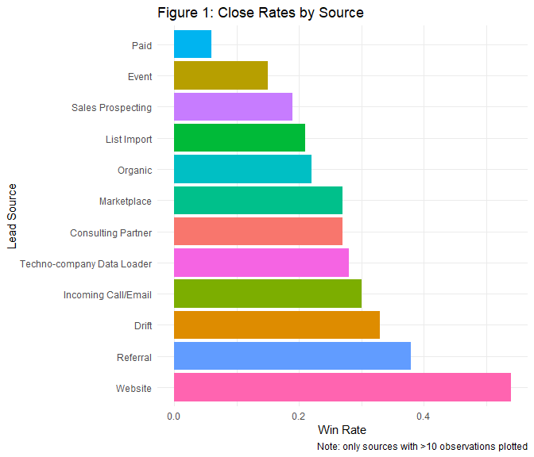

Now, let us look at the breakdown of lead sources as part of overall sales. Below I’ve included a table detailing the sum value of won deals in all categories. The total revenue from these activities is **$25,104,100**

Revenue by Lead Source

| Lead.Source | Count | Total | PctRevenue |
| --- | --- | --- | --- |
| Sales Prospecting | 170 | $8,960,362 | 35.70% |
| Consulting Partner | 160 | $5,070,415 | 20.20% |
| Organic | 119 | $3,474,922 | 13.80% |
| Website | 30 | $1,581,632 | 6.30% |
| Drift | 24 | $1,211,863 | 4.80% |
| Techno-company Data Loader | 49 | $1,039,294 | 4.10% |
| Event | 20 | $964,454 | 3.80% |
| Paid | 22 | $742,856 | 3.00% |
| Unknown Source | 5 | $739,000 | 2.90% |
| List Import | 7 | $525,373 | 2.10% |
| Marketplace | 14 | $445,258 | 1.80% |
| Referral | 5 | $302,108 | 1.20% |
| Incoming Call/Email | 3 | $46,562 | 0.20% |

## **In what ways do partner deals differ from classic deals?**

Moving beyond this, it is of interest to us to uncover the more intangible ways in which the partner network brings in value.

### **Win rate**

One of the most basic of these is the higher rates at which partner deals close. Over this time frame, partner 26% of closed deals with partners were wins while only 20% of closed deals without partners were wins. This increase is likely a result of better prospecting and generation of higher quality leads.

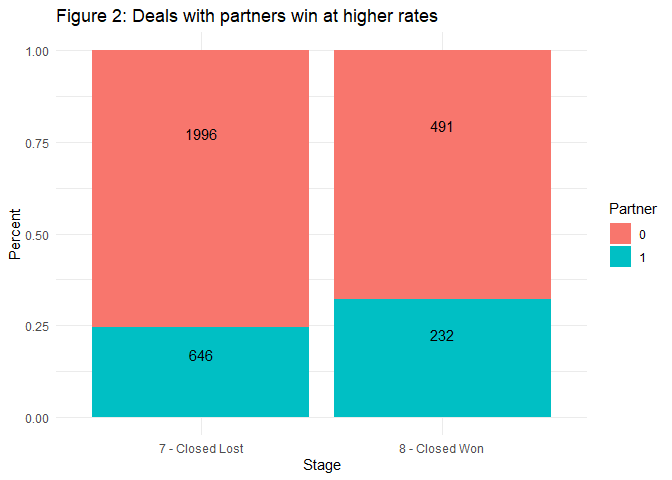

### **Deal size and Account size**

From a broad level, the deal size among partner deals is marginally smaller than closed deals without partners. Closed deals with a partner were on average $36,865.74 while closed deals without a partner were $41,710.44. This comparison doesn’t tell the whole story though, as account sizes differ across categories. The two account sizes referenced in the data can be understood as:

**CAE** (Commercial): Company under $250 million

**EAE** (Enterprise): Company over $250 million

Deals on enterprise accounts were far larger than those on commercial accounts.

Breakdown of deals by account size

| Account Size | Number of Deals | Sum Revenue | Average Deal Size |
| --- | --- | --- | --- |
| Commercial | 300 | $6,475,174 | $21,583.91 |
| Enterprise | 284 | $17,851,762 | $62,858.32 |

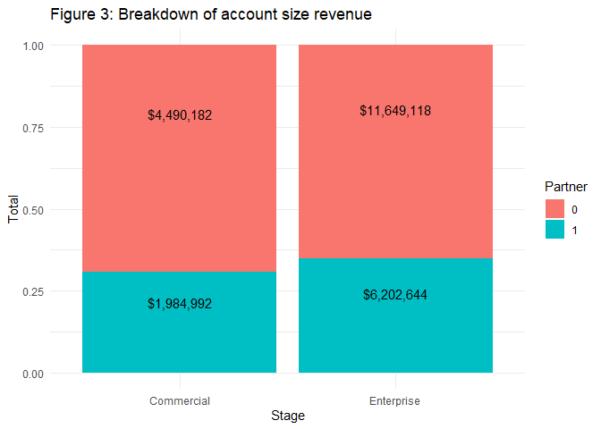

Given that partnered deals are slightly more likely to be enterprise deals. It is surprising that partner deals are generally smaller, given that enterprise deals are larger deals.

How could this be the case?

It turns out that deal size is not consistent across partner/no-partner. Commercial deals with a partner appear to be significantly smaller on average than their non-partnered counterparts.

Different deal sizes in commercial accounts

| Account Size | Partner | Mean Deal Size |
| --- | --- | --- |
| Commercial | 0 | $24,403.17 |
| Commercial | 1 | $17,112.00 |
| Enterprise | 0 | $63,310.42 |
| Enterprise | 1 | $62,026.44 |

### **Time in pipeline**

Another question of interest is whether or not partner deals move through the pipeline at a different speed than non-partnered deals.

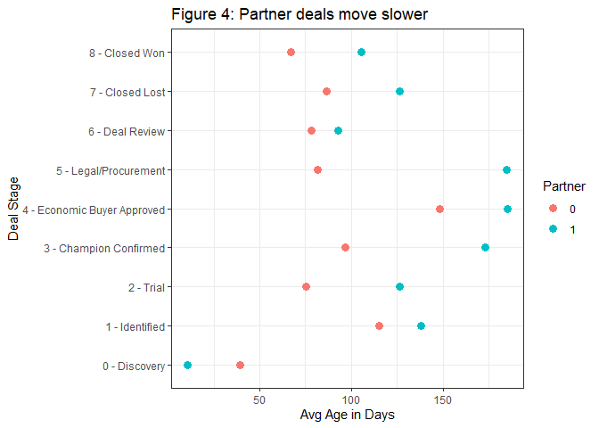

This isn’t inherently a bad thing. Deals with a partner have a fundamentally different approach to non partnered deals, so this may not be a direct comparison.

This comparison is also robust to account size. Overall the smaller commercial accounts take an average of 72 days while the enterprise accounts on average took 85 days to complete. Within these account sizes, the trend of partner deals taking longer remained, as shown below.

Average Deal Length

| Account Size | Partner | Avg Completed Deal Age |
| --- | --- | --- |
| Commercial | 0 | 52 |
| Commercial | 1 | 104 |
| Enterprise | 0 | 72 |
| Enterprise | 1 | 110 |

### **Region**

One of the benefits of a partner network is that partners can provide assistance in their own region, where one might not have much experience.

Closed deals in this data set are most often closed in the United States, and these deals make up $14,099,781 of the total sales.

Excluding these deals, the partner network makes up a larger share of international deals.

Deals excluding the US

| Partner | Sum |
| --- | --- |
| 0 | $6,289,665 |
| 1 | $4,714,655 |

Interestingly, within some countries the partner network makes up a majority of deals. In countries such as the Netherlands, the United Kingdom, New Zealand or Belgium, the partnered deals are more valuable than non partnered deals.

It would be incredibly valuable to the organization to be analyze this trend over time. One of the main limitations of this data set is that it only encompasses one year of observations. There is a chance that the countries with budding partner networks develop into countries where more business is done overall. In other words, a partner in a foreign country might act as a foot in the door to drive future sales.

## **Conclusion**

This new partner network appears to provide valuable opportunities to the Techno-company. It has quickly expanded into countries where little business is done without partners.

There are some distinct differences between partnered deals and non partnered deals. In terms of win rate, partnered deals win more often than their non partnered counterparts. These partnered deals also take significantly longer, due in some part to the number of moving pieces in more complicated deals. Partner deals also appear to be smaller when done with on a commercial account.

The recommended steps going forward would be for the Techno-company to further investigate the ways in which their business is growing. With data over a longer time horizon, decision makers could better analyze the effects of the partner network on expanding the business to new markets. While some of the signs point in this direction from this analysis, it is far from conclusive. With a larger amount of data, the Techno-company would be more able to discern if this partner network helps expansion.